# Project2_Part1_Group22

#### Tristan Jones, Susan Aryal, Suraj Bhatta

#### PS:1486089, 1899326, 1879303

#### Group 22

#### Group Project Classification: Part 1

# Preprocessing

```python
%matplotlib inline
import numpy as np
import matplotlib.pyplot as plt
import pandas as pd
import seaborn as sns
from sklearn.model_selection import train_test_split
```

```python
address = 'heart_failure.csv'
df = pd.read_csv(address)
df = df.drop(['time'], axis=1)
df.head()
```

|  | age | anaemia | creatinine_phosphokinase | diabetes | ejection_fraction | high_blood_pressure | platelets | serum_creatinine | serum_sodium | sex | smoking | DEATH_EVENT |
| --- | --- | --- | --- | --- | --- | --- | --- | --- | --- | --- | --- | --- |
| 0 | 75.0 | 0 | 582 | 0 | 20 | 1 | 265000.00 | 1.9 | 130 | 1 | 0 | 1 |
| 1 | 55.0 | 0 | 7861 | 0 | 38 | 0 | 263358.03 | 1.1 | 136 | 1 | 0 | 1 |
| 2 | 65.0 | 0 | 146 | 0 | 20 | 0 | 162000.00 | 1.3 | 129 | 1 | 1 | 1 |
| 3 | 50.0 | 1 | 111 | 0 | 20 | 0 | 210000.00 | 1.9 | 137 | 1 | 0 | 1 |
| 4 | 65.0 | 1 | 160 | 1 | 20 | 0 | 327000.00 | 2.7 | 116 | 0 | 0 | 1 |

### Feature Types-

- Categorical:
  - Anaemia
  - Diabetes
  - High Blood Pressure
  - Sex
  - Smoking
- Continuous:
  - Age
  - Creatinine Phosphokinase
  - Ejection Fraction
  - Platelets
  - Serum Creatinine
  - Serum sodium
- Note: Time variable does not have any impact on Death event so it was dropped

## Categorical Information

#### Sex: Female = 0, Male = 1

#### Diabetes: Non-Diabetic = 0, Diabetic = 1

#### Anaemia: Non-Anaemic = 0, Anaemic = 1

#### High_blood_pressure: No = 0, Yes = 1

#### Smoking: Non-Smoker = 0, Smoker = 1

#### DEATH_EVENT: Non-Death 0, Death = 1

# Data Cleaning

## Checking and storing column names

```python
col_names = df.columns.values
print(col_names)
```

```
['age' 'anaemia' 'creatinine_phosphokinase' 'diabetes' 'ejection_fraction'
 'high_blood_pressure' 'platelets' 'serum_creatinine' 'serum_sodium' 'sex'
 'smoking' 'DEATH_EVENT']
```

## Checking datatypes

```python
df.info()
```

```
<class 'pandas.core.frame.DataFrame'>
RangeIndex: 299 entries, 0 to 298
Data columns (total 12 columns):
 #   Column                    Non-Null Count  Dtype
---  ------                    --------------  -----
 0   age                       299 non-null    float64
 1   anaemia                   299 non-null    int64
 2   creatinine_phosphokinase  299 non-null    int64
 3   diabetes                  299 non-null    int64
 4   ejection_fraction         299 non-null    int64
 5   high_blood_pressure       299 non-null    int64
 6   platelets                 299 non-null    float64
 7   serum_creatinine          299 non-null    float64
 8   serum_sodium              299 non-null    int64
 9   sex                       299 non-null    int64
 10  smoking                   299 non-null    int64
 11  DEATH_EVENT               299 non-null    int64
dtypes: float64(3), int64(9)
memory usage: 28.2 KB
```

## Checking for missing values

```python
df.isna().head()
```

|  | age | anaemia | creatinine_phosphokinase | diabetes | ejection_fraction | high_blood_pressure | platelets | serum_creatinine | serum_sodium | sex | smoking | DEATH_EVENT |
| --- | --- | --- | --- | --- | --- | --- | --- | --- | --- | --- | --- | --- |
| 0 | False | False | False | False | False | False | False | False | False | False | False | False |
| 1 | False | False | False | False | False | False | False | False | False | False | False | False |
| 2 | False | False | False | False | False | False | False | False | False | False | False | False |
| 3 | False | False | False | False | False | False | False | False | False | False | False | False |
| 4 | False | False | False | False | False | False | False | False | False | False | False | False |

```python
df.isna().sum()
```

```
age                         0
anaemia                     0
creatinine_phosphokinase    0
diabetes                    0
ejection_fraction           0
high_blood_pressure         0
platelets                   0
serum_creatinine            0
serum_sodium                0
sex                         0
smoking                     0
DEATH_EVENT                 0
dtype: int64
```

#### There are no missing values found in the dataset

## Creating Train and Test set

```python
X = df.drop(['DEATH_EVENT'], axis=1)
y = df['DEATH_EVENT']
X_train, X_test, y_train, y_test = train_test_split(X, y, test_size = 0.3, random_state = 123)
```

## Counting Bins

```python
np.bincount(y)
```

```
array([203,  96], dtype=int64)
```

```python
np.bincount(y_train)
```

```
array([150,  59], dtype=int64)
```

```python
np.bincount(y_test)
```

```
array([53, 37], dtype=int64)
```

# Descriptive Statistics

```python
df.describe()
```

|  | age | anaemia | creatinine_phosphokinase | diabetes | ejection_fraction | high_blood_pressure | platelets | serum_creatinine | serum_sodium | sex | smoking | DEATH_EVENT |
| --- | --- | --- | --- | --- | --- | --- | --- | --- | --- | --- | --- | --- |
| count | 299.000000 | 299.000000 | 299.000000 | 299.000000 | 299.000000 | 299.000000 | 299.000000 | 299.00000 | 299.000000 | 299.000000 | 299.00000 | 299.00000 |
| mean | 60.833893 | 0.431438 | 581.839465 | 0.418060 | 38.083612 | 0.351171 | 263358.029264 | 1.39388 | 136.625418 | 0.648829 | 0.32107 | 0.32107 |
| std | 11.894809 | 0.496107 | 970.287881 | 0.494067 | 11.834841 | 0.478136 | 97804.236869 | 1.03451 | 4.412477 | 0.478136 | 0.46767 | 0.46767 |
| min | 40.000000 | 0.000000 | 23.000000 | 0.000000 | 14.000000 | 0.000000 | 25100.000000 | 0.50000 | 113.000000 | 0.000000 | 0.00000 | 0.00000 |
| 25% | 51.000000 | 0.000000 | 116.500000 | 0.000000 | 30.000000 | 0.000000 | 212500.000000 | 0.90000 | 134.000000 | 0.000000 | 0.00000 | 0.00000 |
| 50% | 60.000000 | 0.000000 | 250.000000 | 0.000000 | 38.000000 | 0.000000 | 262000.000000 | 1.10000 | 137.000000 | 1.000000 | 0.00000 | 0.00000 |
| 75% | 70.000000 | 1.000000 | 582.000000 | 1.000000 | 45.000000 | 1.000000 | 303500.000000 | 1.40000 | 140.000000 | 1.000000 | 1.00000 | 1.00000 |
| max | 95.000000 | 1.000000 | 7861.000000 | 1.000000 | 80.000000 | 1.000000 | 850000.000000 | 9.40000 | 148.000000 | 1.000000 | 1.00000 | 1.00000 |

## Interpretation from the statistics:

#### Average age in the data set is around 61 years old with the youngest being 40 and the oldest being 95.

#### The standard deviation of the age is 11.89.

#### Average creatinine phosphokinase is around 582 ranging from 23 to 7861.

#### Average ejection factor is found to be around 38 which can go as much as 80 or as low as 14.

#### The average of serum creatinine level and serum sodium is 1.39 and 136.63 respectively.

## Calculating the correlation of each categorical features with the Death Event

```python
print("Death and male correlation percentage: {0:.2f}%".format(df["DEATH_EVENT"][df["sex"] == 1].value_counts(normalize = True)[1]*100))
print("Death and female correlation percentage: {0:.2f}%".format(df["DEATH_EVENT"][df["sex"] == 0].value_counts(normalize = True)[1]*100))
```

```
Death and male correlation percentage: 31.96%
Death and female correlation percentage: 32.38%
```

```python
print("Death and smoker correlation percentage: {0:.2f}%".format(df["DEATH_EVENT"][df["smoking"] == 1].value_counts(normalize = True)[1]*100))
print("Death and non-smoker correlation percentage: {0:.2f}%".format(df["DEATH_EVENT"][df["smoking"] == 0].value_counts(normalize = True)[1]*100))
```

```
Death and smoker correlation percentage: 31.25%
Death and non-smoker correlation percentage: 32.51%
```

```python
print("Death and diabetic correlation percentage: {0:.2f}%".format(df["DEATH_EVENT"][df["diabetes"] == 1].value_counts(normalize = True)[1]*100))
print("Death and non-diabetic correlation percentage: {0:.2f}%".format(df["DEATH_EVENT"][df["diabetes"] == 0].value_counts(normalize = True)[1]*100))
```

```
Death and diabetic correlation percentage: 32.00%
Death and non-diabetic correlation percentage: 32.18%
```

```python
print("Death and anaemic correlation percentage: {0:.2f}%".format(df["DEATH_EVENT"][df["anaemia"] == 1].value_counts(normalize = True)[1]*100))
print("Death and non-anaemic correlation percentage: {0:.2f}%".format(df["DEATH_EVENT"][df["anaemia"] == 0].value_counts(normalize = True)[1]*100))
```

```
Death and anaemic correlation percentage: 35.66%
Death and non-anaemic correlation percentage: 29.41%
```

```python
print("Death and high blood pressure correlation percentage: {0:.2f}%".format(df["DEATH_EVENT"][df["high_blood_pressure"] == 1].value_counts(normalize = True)[1]*100))
print("Death and non-high blood pressure correlation percentage: {0:.2f}%".format(df["DEATH_EVENT"][df["high_blood_pressure"] == 0].value_counts(normalize = True)[1]*100))
```

```
Death and high blood pressure correlation percentage: 37.14%
Death and non-high blood pressure correlation percentage: 29.38%
```

## Findings from the correlation calculation:

#### There is high correlation percentage in dead patients that were Aneamic and have high blood pressure.

#### Female have a slightly higher death rate than males.

#### Although odd, non-smokers have a slightly higher death rate than smokers.

#### The diabetic and non-diabietic ones tend to have almost same death rates.

# Feature vs Death

### Comparing each feature with our label: Death Event and visualizing the statistics.

## Age vs Death

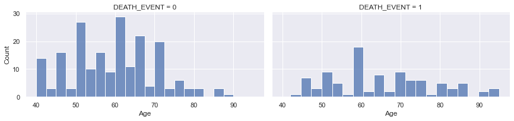

```python
import seaborn as sns
sns.set();

g = sns.FacetGrid(df, col = "DEATH_EVENT", aspect = 2)
g.map(sns.histplot, 'age', bins = 20)
g.set_axis_labels("Age", "Count")
```

#### Among the dead ones, the number of people dead is significantly large for age around 60 compared to other age groups.

## Anemia vs Death

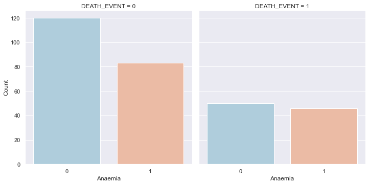

```python
g = sns.catplot(x="anaemia", kind="count", palette="RdBu_r", data=df, col="DEATH_EVENT")
g.set_axis_labels("Anaemia", "Count")
```

#### There is not much difference in the number of anemic and non-anemic people who are dead.

## Creatinine Phosphokinase vs Death

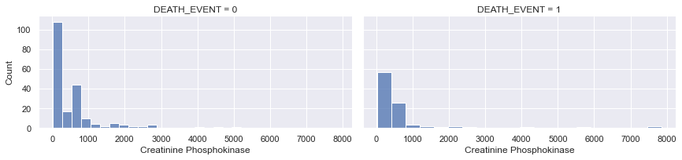

```python
g = sns.FacetGrid(df, col = "DEATH_EVENT", aspect = 2)
g.map(sns.histplot, 'creatinine_phosphokinase', bins = 20)
g.set_axis_labels("Creatinine Phosphokinase", "Count")
```

#### Almost all poeple had the creatinine phosphokinase level ranging from 0 to 1000 while the maximum value is 7861 which suggests us we have some outliers. The minimum value is 23 and the standard deviation is 970.29.

## Diabetes vs Death

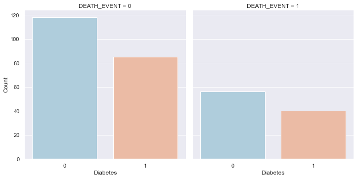

```python
g = sns.catplot(x="diabetes", kind="count", palette="RdBu_r", data=df, col="DEATH_EVENT")
g.set_axis_labels("Diabetes", "Count")
```

#### The diabetic and non-diabietic ones tend to have almost same death rates but our sample (dataset) has slightly more non-diabetic people than diabetic ones.

## Ejection Fraction vs Death

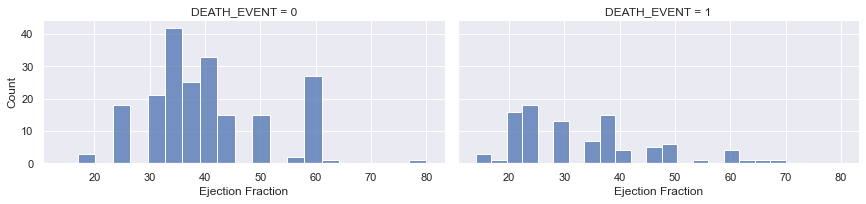

```python
g = sns.FacetGrid(df, col = "DEATH_EVENT", aspect = 2)
g.map(sns.histplot, 'ejection_fraction', bins = 20)
g.set_axis_labels("Ejection Fraction", "Count")
```

#### The lower ejection factor resulted in death event while the non-dead ones have higher ejection factor.

## High Blood Pressure vs Death

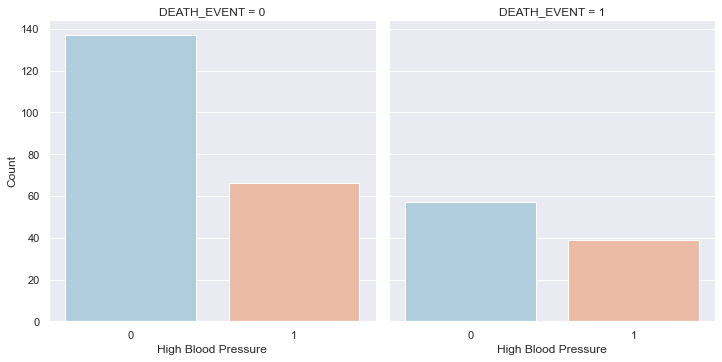

```python
g = sns.catplot(x="high_blood_pressure", kind="count", palette="RdBu_r", data=df, col="DEATH_EVENT")
g.set_axis_labels("High Blood Pressure", "Count")
```

#### Since there is high correlation percentage in dead patients that had high blood pressure, the most poeple with low blood pressure are not dead.

## Platelets vs Death

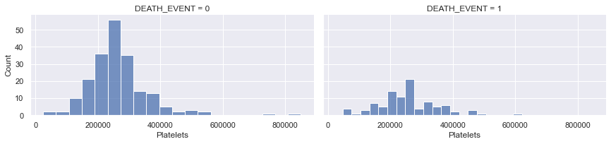

```python
g = sns.FacetGrid(df, col = "DEATH_EVENT", aspect = 2)
g.map(sns.histplot, 'platelets', bins = 20)
g.set_axis_labels("Platelets", "Count")
```

#### From the dataset, the number of platelets is at the peak around 20000 to 400000. Some poeple had much higher number of platelets b ut that doesn't really determine the death event.

## Serum Creatinine vs Death

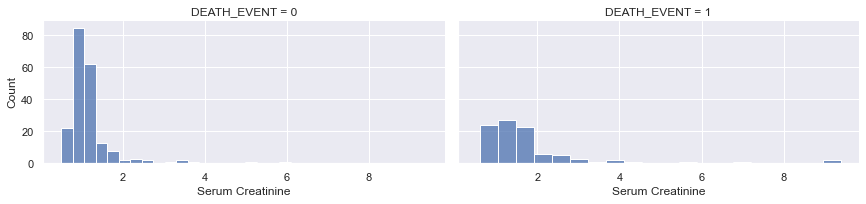

```python
g = sns.FacetGrid(df, col = "DEATH_EVENT", aspect = 2)
g.map(sns.histplot, 'serum_creatinine', bins = 20)
g.set_axis_labels("Serum Creatinine", "Count")
```

## Serum Sodium vs Death

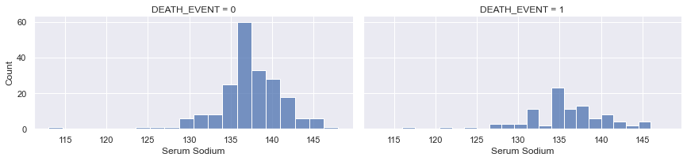

```python
g = sns.FacetGrid(df, col = "DEATH_EVENT", aspect = 2)
g.map(sns.histplot, 'serum_sodium', bins = 20)
g.set_axis_labels("Serum Sodium", "Count")
```

#### The level of Serum Sodium doesn't really have much effect on the death event. Our sample has the data with serum sodum level mostly close to the range 135-140. The average is 136.63

## Sex vs Death

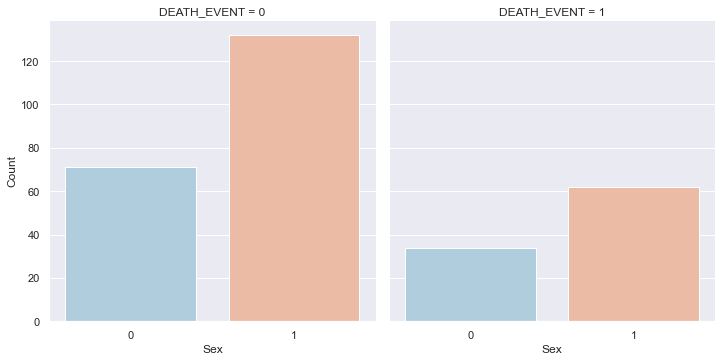

```python
g = sns.catplot(x="sex", kind="count", palette="RdBu_r", data=df, col="DEATH_EVENT")
g.set_axis_labels("Sex", "Count")
```

#### The number of males in the dataset is higher than the females, however percentage wise, females have a higher death rate

## Smoking vs Death

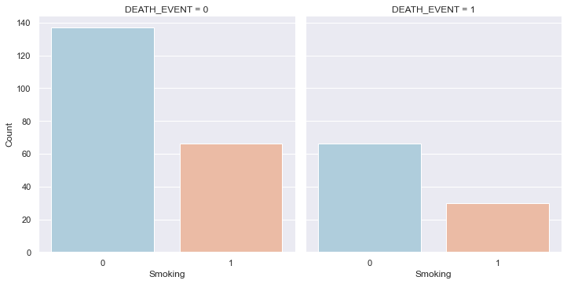

```python
g = sns.catplot(x="smoking", kind="count", palette="RdBu_r", data=df, col="DEATH_EVENT")
g.set_axis_labels("Smoking", "Count")
```

```python
df
```

|  | age | anaemia | creatinine_phosphokinase | diabetes | ejection_fraction | high_blood_pressure | platelets | serum_creatinine | serum_sodium | sex | smoking | DEATH_EVENT |
| --- | --- | --- | --- | --- | --- | --- | --- | --- | --- | --- | --- | --- |
| 0 | 75.0 | 0 | 582 | 0 | 20 | 1 | 265000.00 | 1.9 | 130 | 1 | 0 | 1 |
| 1 | 55.0 | 0 | 7861 | 0 | 38 | 0 | 263358.03 | 1.1 | 136 | 1 | 0 | 1 |
| 2 | 65.0 | 0 | 146 | 0 | 20 | 0 | 162000.00 | 1.3 | 129 | 1 | 1 | 1 |
| 3 | 50.0 | 1 | 111 | 0 | 20 | 0 | 210000.00 | 1.9 | 137 | 1 | 0 | 1 |
| 4 | 65.0 | 1 | 160 | 1 | 20 | 0 | 327000.00 | 2.7 | 116 | 0 | 0 | 1 |
| ... | ... | ... | ... | ... | ... | ... | ... | ... | ... | ... | ... | ... |
| 294 | 62.0 | 0 | 61 | 1 | 38 | 1 | 155000.00 | 1.1 | 143 | 1 | 1 | 0 |
| 295 | 55.0 | 0 | 1820 | 0 | 38 | 0 | 270000.00 | 1.2 | 139 | 0 | 0 | 0 |
| 296 | 45.0 | 0 | 2060 | 1 | 60 | 0 | 742000.00 | 0.8 | 138 | 0 | 0 | 0 |
| 297 | 45.0 | 0 | 2413 | 0 | 38 | 0 | 140000.00 | 1.4 | 140 | 1 | 1 | 0 |
| 298 | 50.0 | 0 | 196 | 0 | 45 | 0 | 395000.00 | 1.6 | 136 | 1 | 1 | 0 |

299 rows × 12 columns

```python
# We are now checking which factors are more significant in predicting the death event.
```

```python
data = df.dropna(subset = ['age','anaemia', 'creatinine_phosphokinase','diabetes','ejection_fraction','high_blood_pressure','platelets','serum_sodium','sex','smoking'])
data.head()
```

|  | age | anaemia | creatinine_phosphokinase | diabetes | ejection_fraction | high_blood_pressure | platelets | serum_creatinine | serum_sodium | sex | smoking | DEATH_EVENT |
| --- | --- | --- | --- | --- | --- | --- | --- | --- | --- | --- | --- | --- |
| 0 | 75.0 | 0 | 582 | 0 | 20 | 1 | 265000.00 | 1.9 | 130 | 1 | 0 | 1 |
| 1 | 55.0 | 0 | 7861 | 0 | 38 | 0 | 263358.03 | 1.1 | 136 | 1 | 0 | 1 |
| 2 | 65.0 | 0 | 146 | 0 | 20 | 0 | 162000.00 | 1.3 | 129 | 1 | 1 | 1 |
| 3 | 50.0 | 1 | 111 | 0 | 20 | 0 | 210000.00 | 1.9 | 137 | 1 | 0 | 1 |
| 4 | 65.0 | 1 | 160 | 1 | 20 | 0 | 327000.00 | 2.7 | 116 | 0 | 0 | 1 |